# Pendulum Math

[figure not shown]

newtons second law of motion is: $F=ma$

F is the force m is the mass and a is the acceleration. the force due to gravity is therefore $mg$

Where g is the acceleration due to gravity, on earth that is $-9.8 m/s^2$

torque is a rotational force where: $t=rF_t$

t is the torque r is the length and $F_t$ is the tangent force

for a pendulum gravity is always down. to figure out the torque that gravity makes, you have to find how much gravity is on the angle 90 degrees from the radius (the tangent). Then you use: $\sin(\theta)=\frac{opposite}{hypotenuse}$

where opposite is the tangent force and hypotenuse is gravity

therefore the tangent force is given by: $mg\sin(\theta)=F_t$

$t=rmg\sin(\theta)$

Angular momentum $t=m\alpha$

where $\alpha$ is angular acceleration in radiansper second squared

The distance around the circle is $c=r\theta$

So the angular velocity is the dirivitave of c: $\frac{dc}{dt}=r\frac{d\theta}{dt}$

so the angular acceleration is: $\alpha=r\frac{d^2\theta}{dt^2}$

So the torque from this momentum is $mr\alpha$

These two torques balance (This is newtons third law). So, the equation for a pendulum is: $r\frac{d^2\theta}{dt^2}=-g\sin(\theta)$

$\frac{d^2\theta}{dt^2}=\frac{-g}{r}\sin(\theta)$

```python
%matplotlib inline
```

```python
import matplotlib.pylab as plt
import numpy as np
import time
from IPython import display
import timeit
```

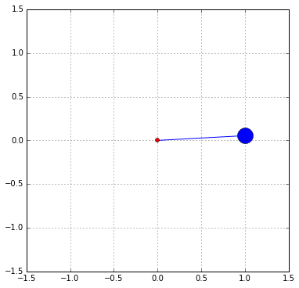

```
6.96213293076
```

```python
import matplotlib.pylab as plt
import numpy as np
import time
from IPython import display
import timeit

r=1.0        #measured in meters
g=-9.8     #the acceleration due to the gravity of earth in m/s^2
theta=np.pi*3/2+3#starting theta
dtheta=0
run_time = 5. #seconds to simulate
dt = 0.1 #seconds (10ms)

#plt.figure(figsize=(12,12))
#plt.axes().set_aspect('equal')
start = timeit.default_timer()

#Your statements here

for t in range(0,np.floor(run_time/dt).astype(np.int64)):
    ddtheta=-g/r*np.sin(theta)*dt**2
    dtheta=dtheta+ddtheta
    theta=theta+dtheta

    x=np.sin(theta)*r
    y=np.cos(theta)*r

    plt.figure(figsize=(6,6))
    plt.axis([-1.5,1.5,-1.5,1.5])
    plt.grid("on")
    plt.axes().set_aspect('equal')
    plt.plot([0,x],[0,y])
    plt.plot(0,0,"ro",markersize=5)
    plt.plot(x,y,"bo",markersize=20)

    display.clear_output(wait=True)
    #display.display(plt.gcf())
    #plt.clf()
    plt.show()
    #time.sleep(0.1)

plt.close()
stop = timeit.default_timer()

print stop - start #run time
```